# EX2306 Event Logs vs Subject Matter Expert QAQC Comparison

# Introduction

#### The purpose of this document is to compare the Event Logs for EX2306 with the Subject Matter Expert (SME) QAQC’d dataset provided by the DARC Lab at UH Manoa. A total of 1627 observations were made during the dive while 32,507 were created by the DARC lab. The tables and figures below demonstrate how this breaks down by individual dive and by dive and taxa. Note Dive 16 was not completed due to high turbidity and no annotations were created (Candio et al. *in prep*).

|  | Dive | data_type | n_obs |
| --- | --- | --- | --- |
| 1 | EX2306_Dive01 | Event_log | 90 |
| 2 | EX2306_Dive01 | SME_QAQC | 932 |
| 3 | EX2306_Dive02 | Event_log | 12 |
| 4 | EX2306_Dive02 | SME_QAQC | 463 |
| 5 | EX2306_Dive03 | Event_log | 63 |
| 6 | EX2306_Dive03 | SME_QAQC | 2442 |
| 7 | EX2306_Dive04 | Event_log | 48 |
| 8 | EX2306_Dive04 | SME_QAQC | 1019 |
| 9 | EX2306_Dive05 | Event_log | 103 |
| 10 | EX2306_Dive05 | SME_QAQC | 2947 |

[output cut: 26 more lines]

#### Figures 1-18: Total number of biological observations created by real-time annotations (Event_log) and the DARC lab QAQC process (SME_QAQC) for each dive conducted during EX2306. Note the scales on the Y axis are variable by dive.

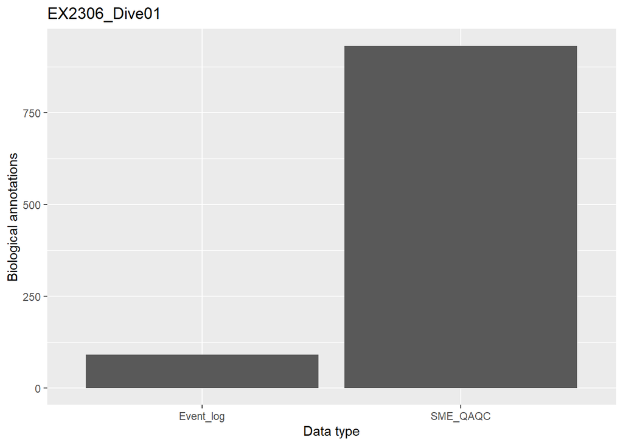

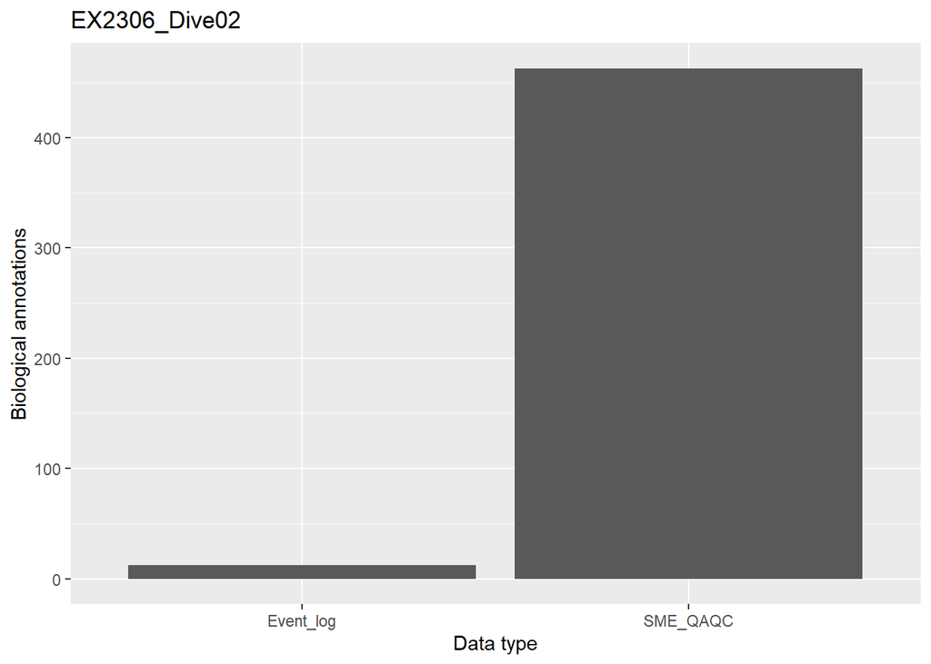

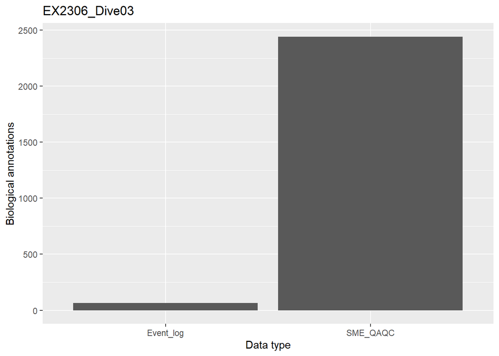

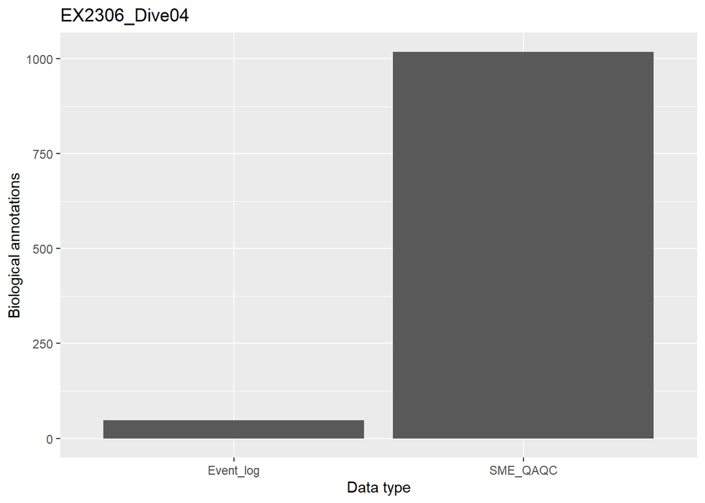

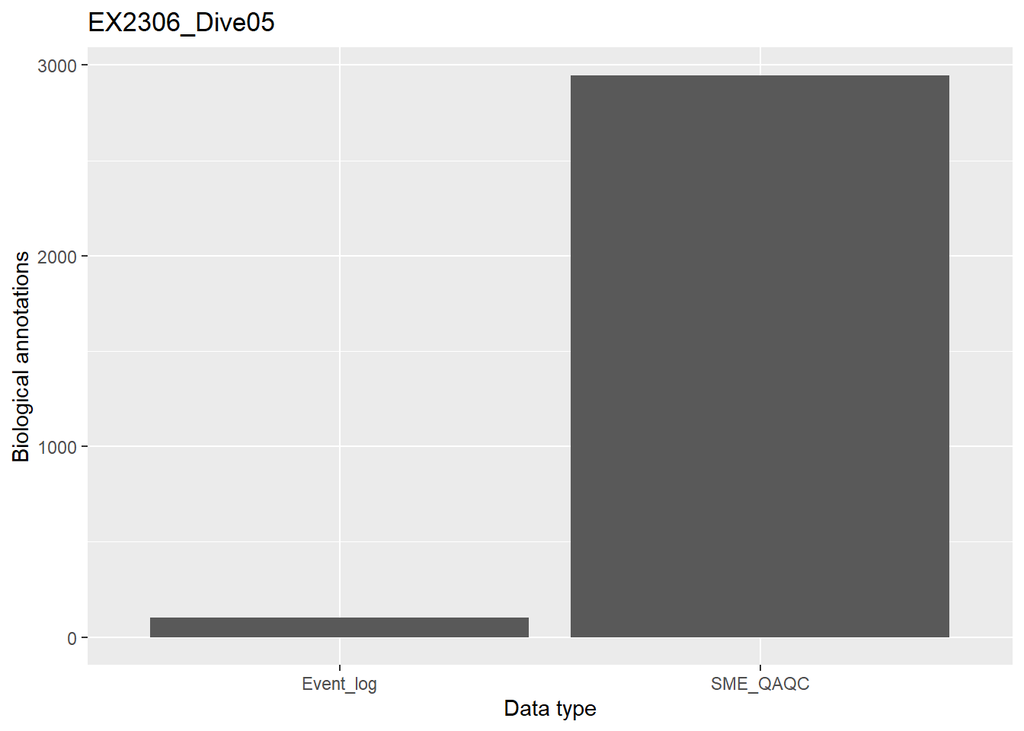

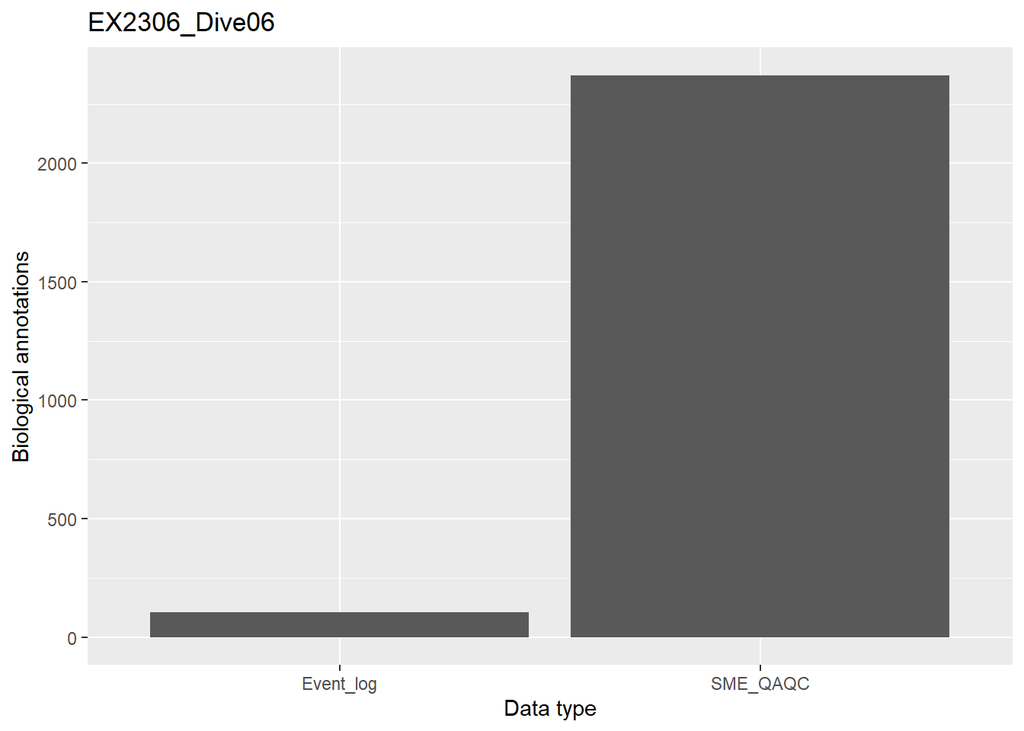

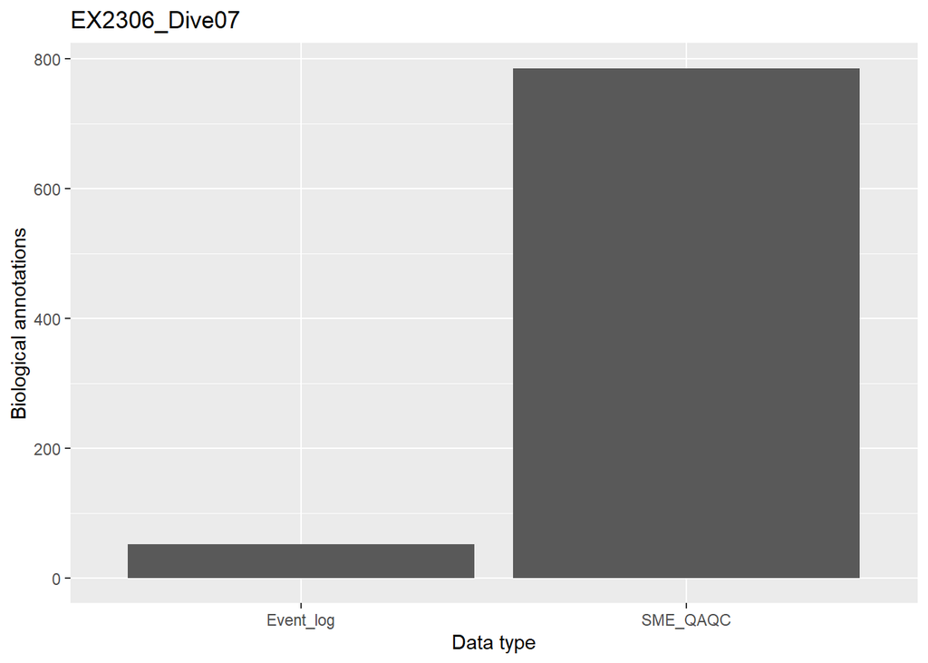

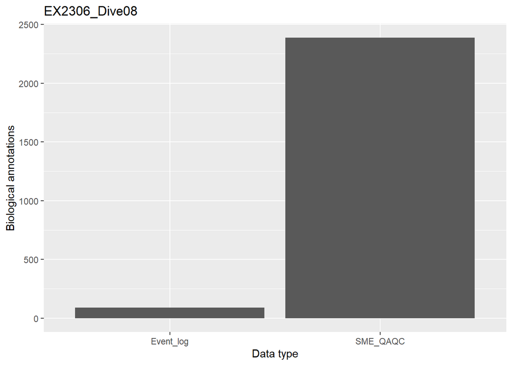

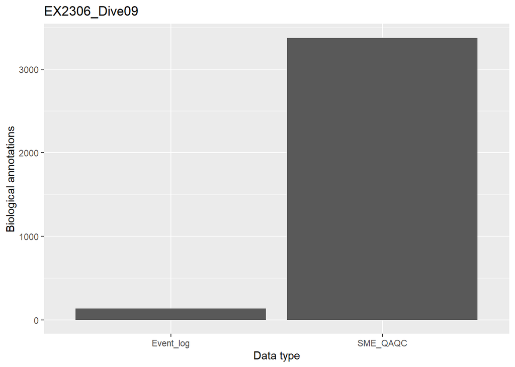

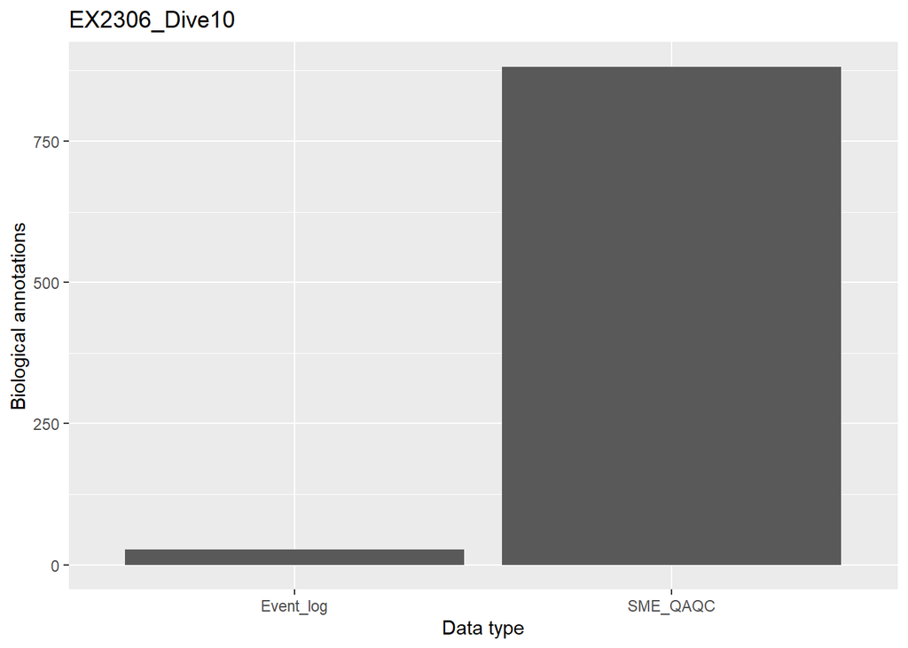

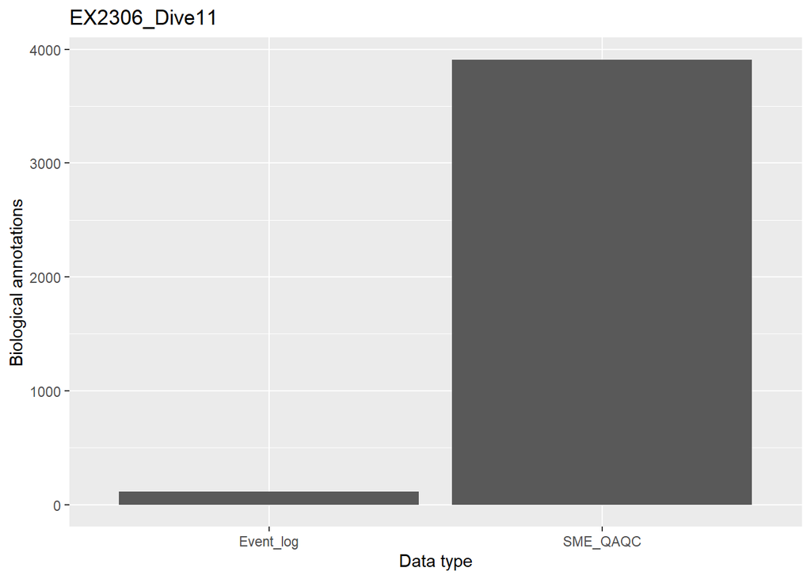

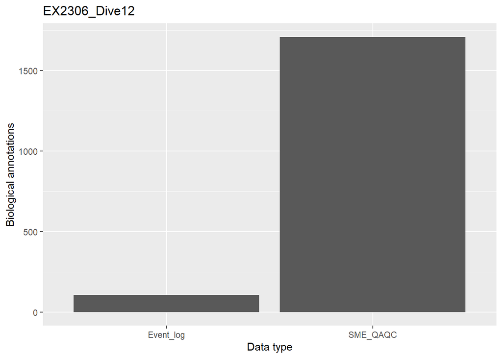

[6 more figures not shown]

|  | Dive | data_type | TaxonRank | n_obs |
| --- | --- | --- | --- | --- |
| 1 | EX2306_Dive01 | Event_log | Class | 34 |
| 2 | EX2306_Dive01 | Event_log | Family | 13 |
| 3 | EX2306_Dive01 | Event_log | Genus | 11 |
| 4 | EX2306_Dive01 | Event_log | Order | 9 |
| 5 | EX2306_Dive01 | Event_log | Phylum | 16 |
| 6 | EX2306_Dive01 | Event_log | Species | 5 |
| 7 | EX2306_Dive01 | Event_log | Subclass | 1 |
| 8 | EX2306_Dive01 | Event_log | Subfamily | 1 |
| 9 | EX2306_Dive01 | Event_log | Gigaclass | 0 |
| 10 | EX2306_Dive01 | Event_log | Infraclass | 0 |

[output cut: 620 more lines]

#### Figures 19-36: Total number of biological observations created by real-time annotations (Event_log) and the DARC lab QAQC process (SME_QAQC) by taxa for each dive conducted during EX2306.

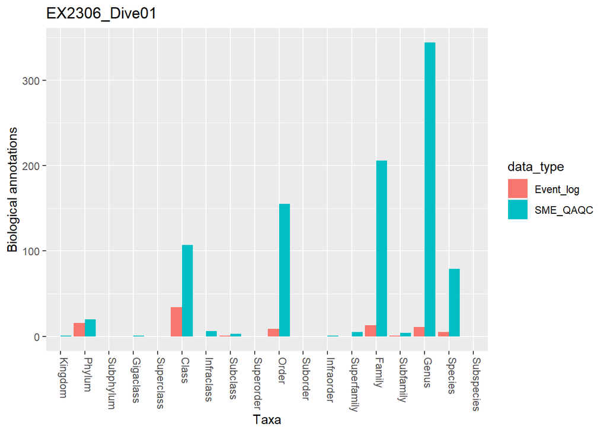

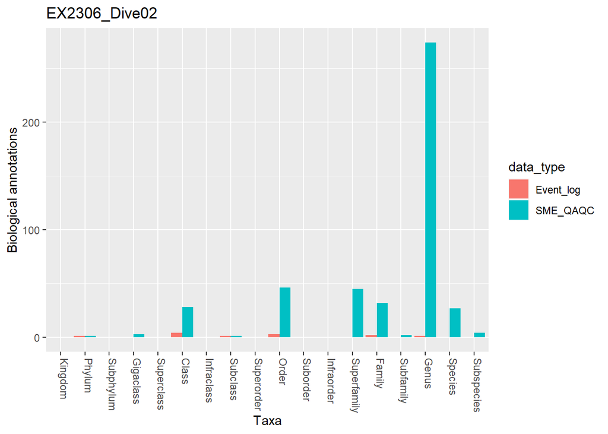

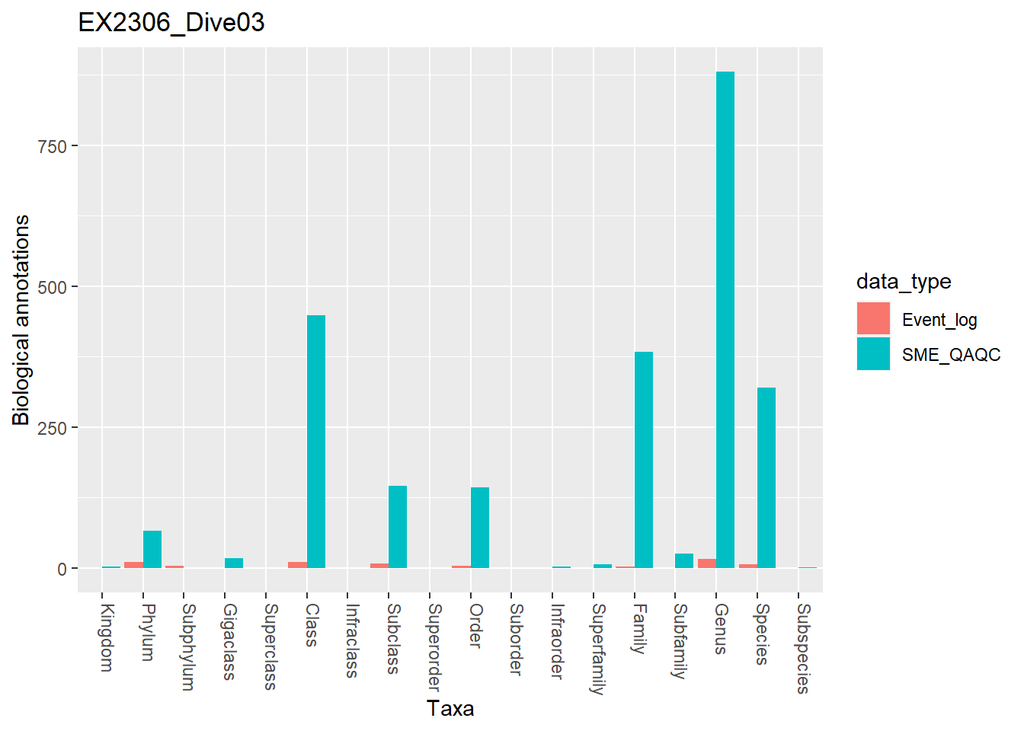

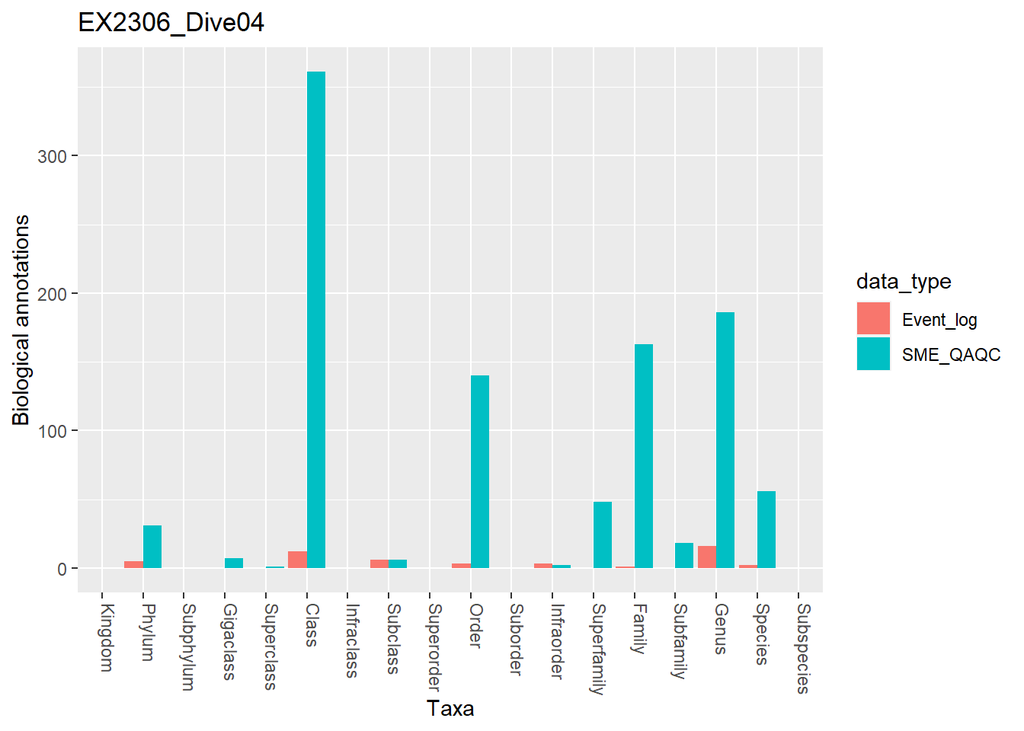

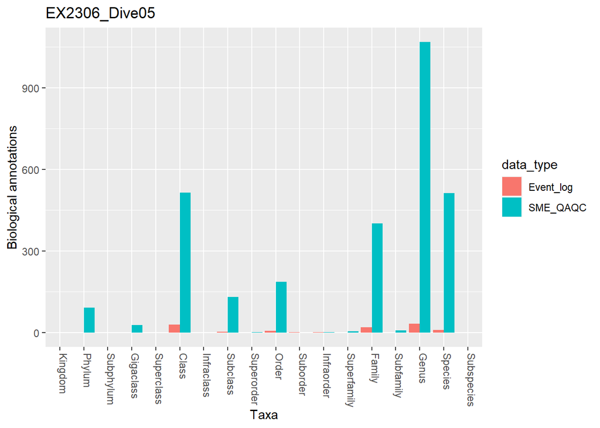

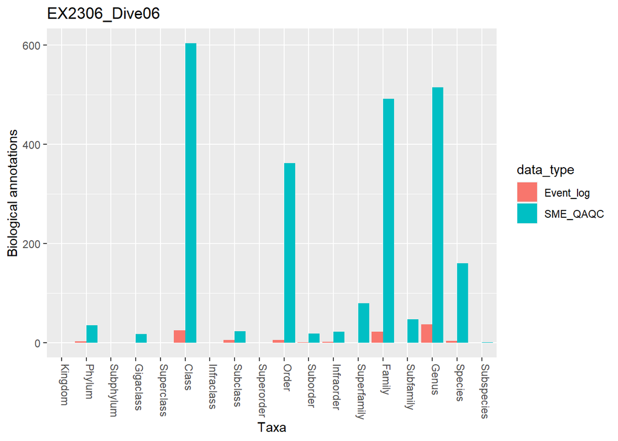

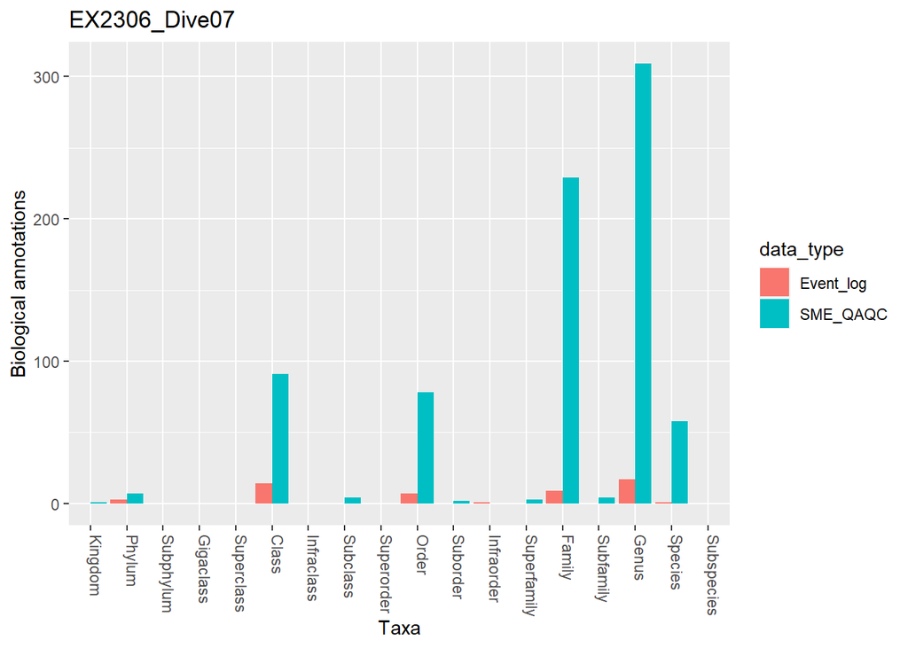

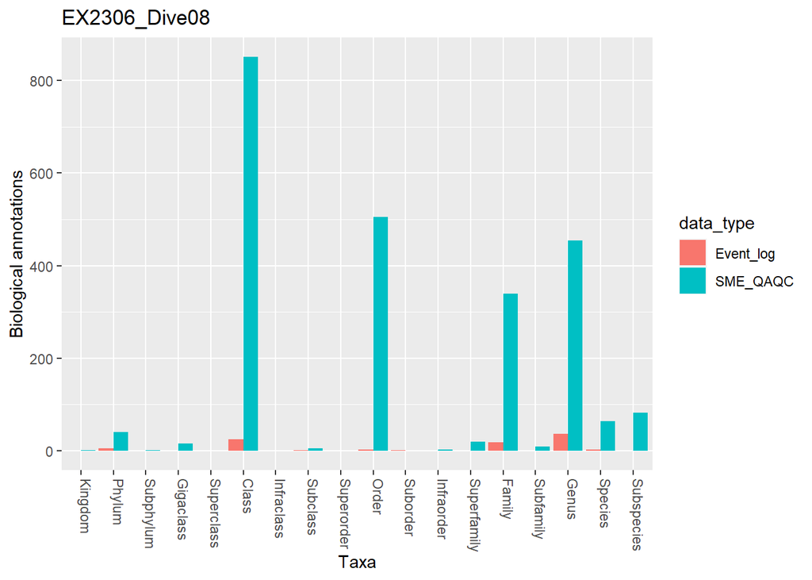

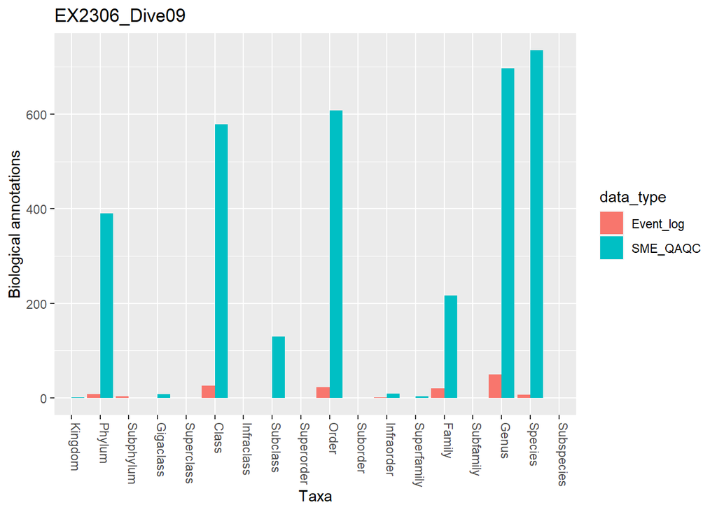

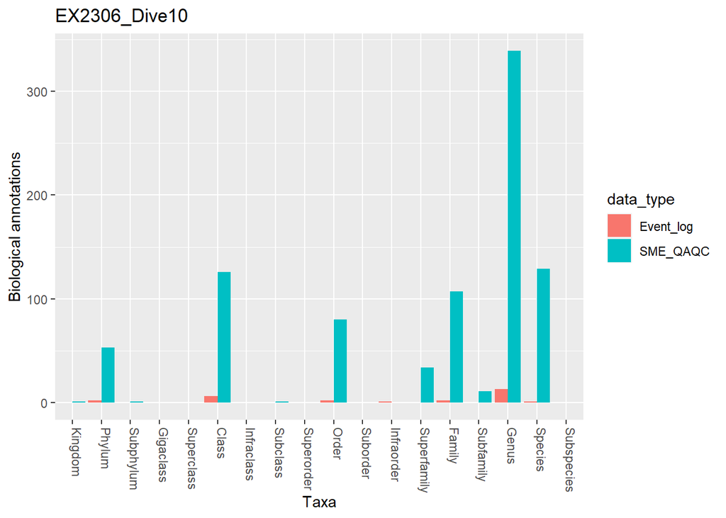

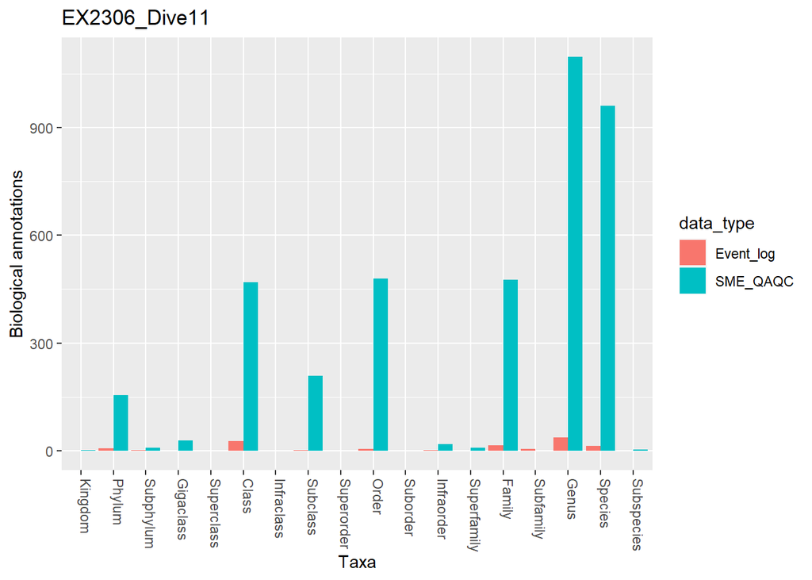

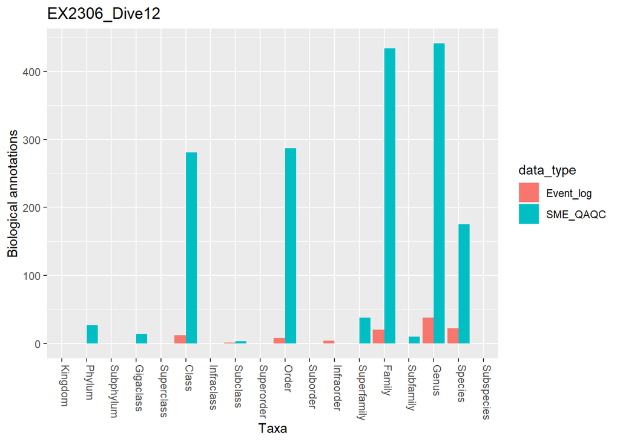

[6 more figures not shown]

#### Figures 37-54: Total number of biological observations created by real-time annotations (Event_log) and the DARC lab QAQC process (SME_QAQC) by taxa for each dive conducted during EX2306. Unique colors represent the diversity of taxa within a given taxonomic level. For example, every unique color in the genus bar represents an indivudal genus identified. Legend is not shown because it is too large. A total of 748 unique taxa were identified on this expedition.

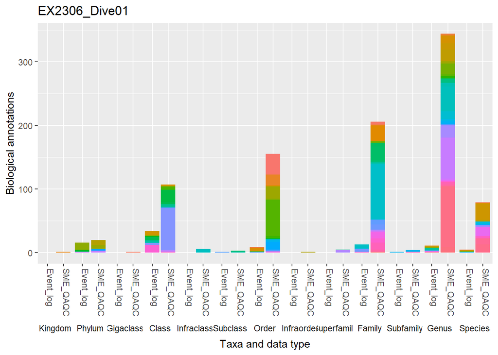

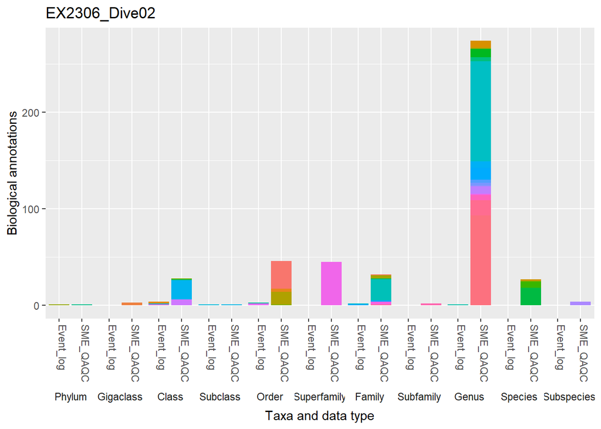

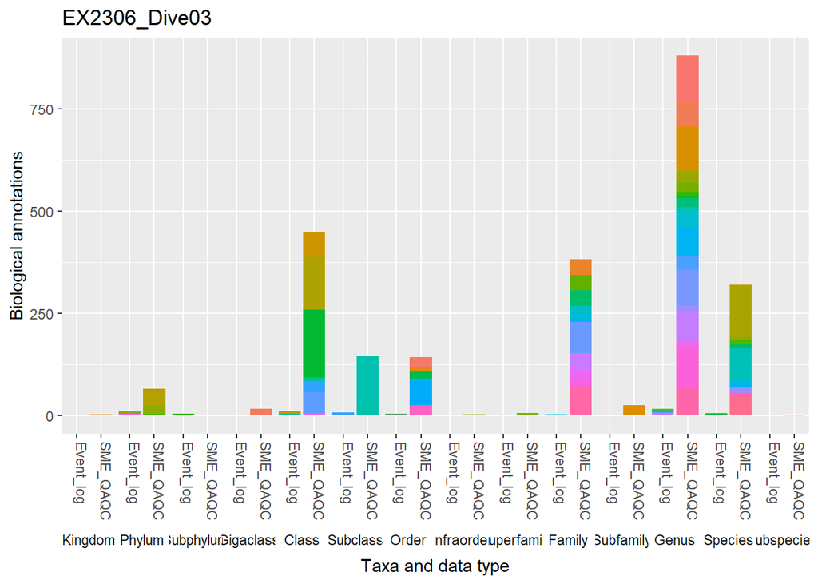

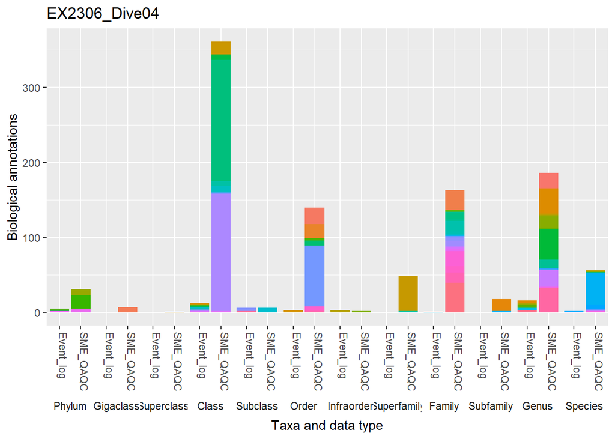

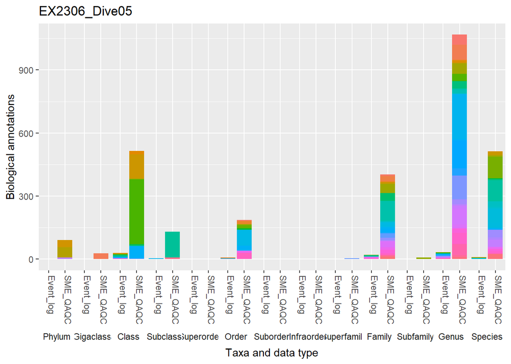

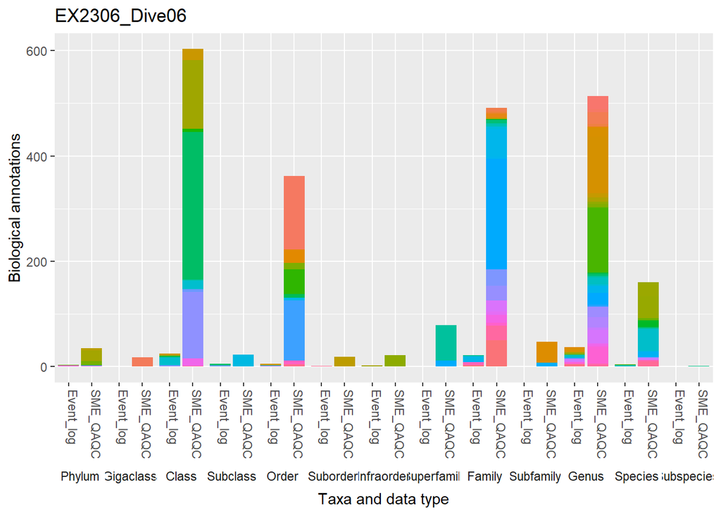

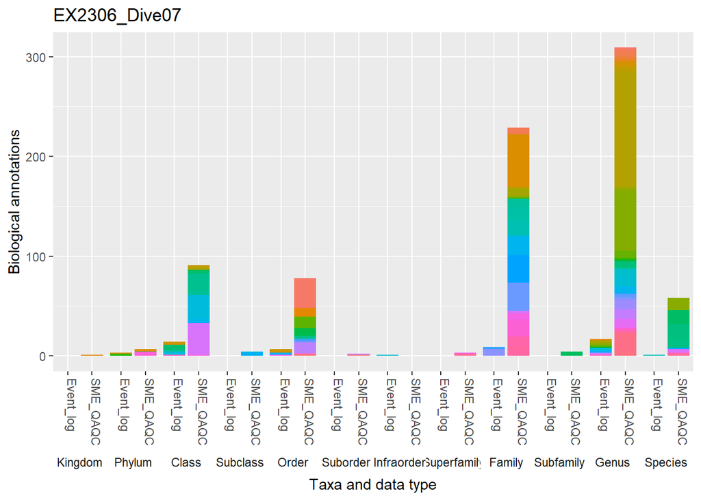

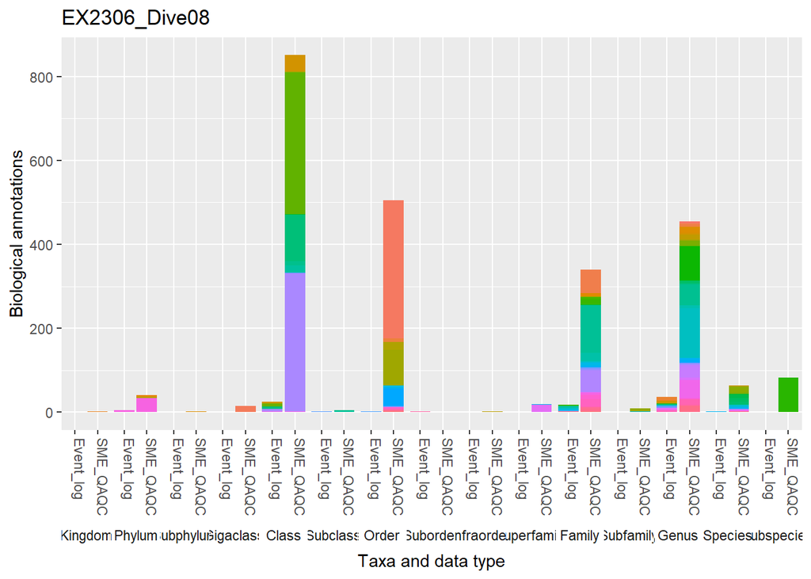